# Shiny meet Electron - Quickly Turn your Shiny app into a standalone desktop app

July 12, 2018

## Overview

The Columbus Collaboratory Team and Me

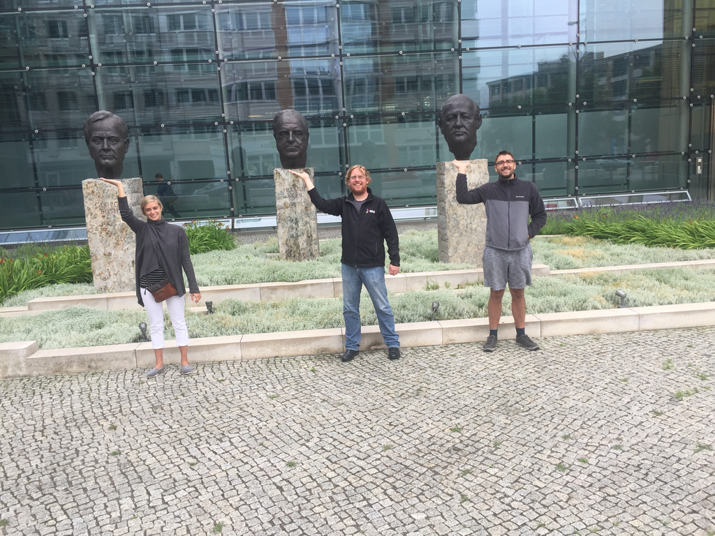

- Electron & Shiny:
  - We know Shiny, but What is Electron?
  - How do Electron & Shiny work together?
  - Electron vs. Other deployment options
  - How can I use Electron to deploy a basic ShinyApp?
  - Intermediate Use Case
  - Additional Considerations
- Materials: To use Electron
  - https://github.com/ColumbusCollaboratory/electron-quick-start
- Material: Presentation Content
  - https://github.com/ksasso/useR_electron_meet_shiny

## We know Shiny, but what is Electron?

**Electron**

- Electron is a chromium web browser and a Node.js runtime brought together to allow us to build thick client applications on any platform using web technologies
- Allow users to create native applications with web technologies like JavaScript, HTML, CSS, and of course, Shiny!
- Skype, Atom, Slack, Visual Studio Code, and many other Apps built on Electron
- Chromium and Node.js together launch an instance of a browser window in electron

**Electron, R, and RPortable**

- Collaboratory team made the code changes necessary to include [RPortable](https://sourceforge.net/projects/rportable/) within Electron
  - We packaged up R alongside Node.js and Chromium
  - We then reference R based on its relative path

## We know Shiny, but what is Electron?

[ElectronJS](https://electronjs.org/)

[interactive chart not shown]

## How do Electron & Shiny work together?

##### Electron, R, and RPortable

```javascript
var appPath = path.join(app.getAppPath(), "app.R" )
var execPath = "RScript"
if(process.platform == WINDOWS){
  killStr = "taskkill /im Rscript.exe /f"
  appPath = appPath.replace(/\\/g, "\\\\");
  execPath = path.join(app.getAppPath(), "R-Portable-Win", "bin", "RScript.exe" )
} else if(process.platform == MACOS){
  //killStr = 'pkill -9 "R"'
  execPath = path.join(app.getAppPath(), "R-Portable-Mac", "bin", "Rscript" )
} else {
  console.log("not on windows or macos?")
  throw new Error("not on windows or macos?")
}
```

## How do Electron & Shiny work together?

##### Node.js, Chromium, and thick client applications

- Thick Client Apps
  - Provide functionality independent of a remote internet server
  - Run both the user interface and server logic on your computer
- Node.js
  - Main process, is like the server side process in standard web apps
  - We use Node.js main process to launch the shiny app by redirecting the rendered content to be the URL that the shinyApp is running on (i.e., my home IP address and default port)
- Chromium
  - Web browser - the key to the user-interface
  - Provides a window to the shinyApp
  - We call the shinyApp function just like you would in RStudio and then direct chormium to our local port where shiny is running

## Electron vs. Other deployment options

- Deploy to the cloud: Shinyapps.io
  - Deploy up to 5 apps 25 active hours, for free.
  - User authentication starting at $99/month
  - No hardware, installation or contract required
  - Requires sending data to the cloud
- Deploy on-premises: Shiny Server
  - Deployed behind your firewall
  - Enterprise grade scaling, security and admin features
  - IT involvement: you install it and you manage it
- Deploy on-premises Commercial: Shiny Server Pro
  - Deploy shinyApp behind a firewall
  - IT involvement required and only supported on Linux
  - Increased access controls i(i.e., SSL, LDAP, Active Directory)
- Deploy on-premises Commercial: RStudio Connect
  - Added capabilities including in-org publishing and scheduling of multiple content types
- Creative option: Docker Containers
  - Still requires heavy IT involvement to set up initial docker environment

## Use Electron to deploy a basic ShinyApp

[video not shown]

https://github.com/ksasso/useR_electron_meet_shiny

## Intermediate Use Case

##### Real World Example: Automating manual cleansing and manipulation done in excel

- All cleaning previously done in excel programmed in R
- User could then query database every week within Shiny application and then download results (how did that work?)
- Packages Used
  - DT, openxlsx, shinydashboard, plyr, dplyr, lubridate, RODBC, zoo
- Key R Functions:
  - fileInput, textInput, actionButton, reactive, sqlQuery, downloadButton
- Special adjustments
  - On Windows: Rtools (for windows) and REnviron.site modification
  - REnviro.site file `{js}PATH="${PATH};${R_HOME}\Rtools\bin`
  - On Both: Download new packages

Shiny App for Automation

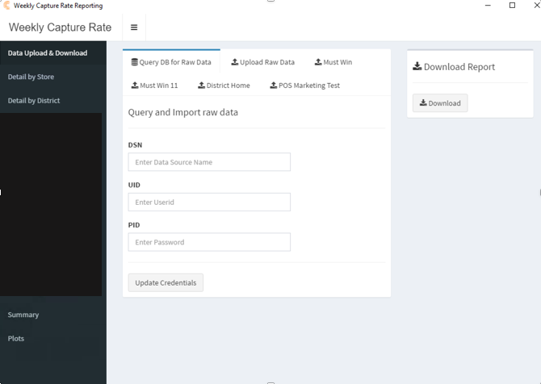

## Intermediate Use Case: New Shiny app.R

[video not shown]

## Intermediate Use Case: New Packages

[video not shown]

## Intermediate Use Case

##### Real World Example: Getting a model into users hands quickly

- Users wanted to better predict risk of large IT project portfolios
- Built a model in XGBoost. User wanted to run model monthly to test it out
- Used Electron to package: trained model object, cleansing required, predict function to apply model, download/upload for new runs and results
- Packages Used:
  - dplyr, tidyr, ggplot2, Matrix, xgboost, openxlsx, scales, shiny, shinydashboard
- Key R Functions:
  - fileInput, textInput, actionButton, reactive,downloadButton, selectizeInput, renderPlot
- Special adjustments
  - Data stripped from XGBoost train object

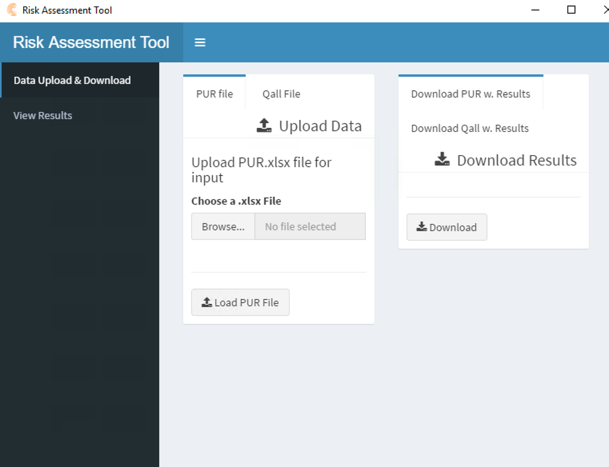

## Additional Considerations & Resources

- Application size
  - Stripping particularly large dependencies (i.e., BH package)
  - Removing R-Portable-Mac or R-Portable-Win depending on OS
- Always best to start fresh
  - Recommend only running "npm run package-win" once in a given clone to create out directory
- [Many Tutorials on RStudio Website](https://shiny.rstudio.com/tutorial/):
  - Some personal favorite sections include the Get Started Video Tutorials, The Gallery, and several of the Articles on Special issues.
  - Some of the most frequently used special issues for me included Dashboards, Reacitivty, and Inputs/Outputs
- [Everything you need is on the Collaboratory's public GitHub Repo!](https://github.com/ColumbusCollaboratory/electron-quick-start)